# 9.2 - Introducción al análisis de series temporales

## Series sobrepuestas, mismo panel (xts)

- `multi.panel=TRUE` representa una serie en cada panel (por defecto `FALSE`, como aquí).

```r
plot(x = prices_xts, xlab = "Tiempo", ylab="log10(precio ajus.)", ylim = c(0.8, 3.3),
     major.ticks = "years", minor.ticks = FALSE, col=brw_col[1:2], main="Precios ajustados")
```

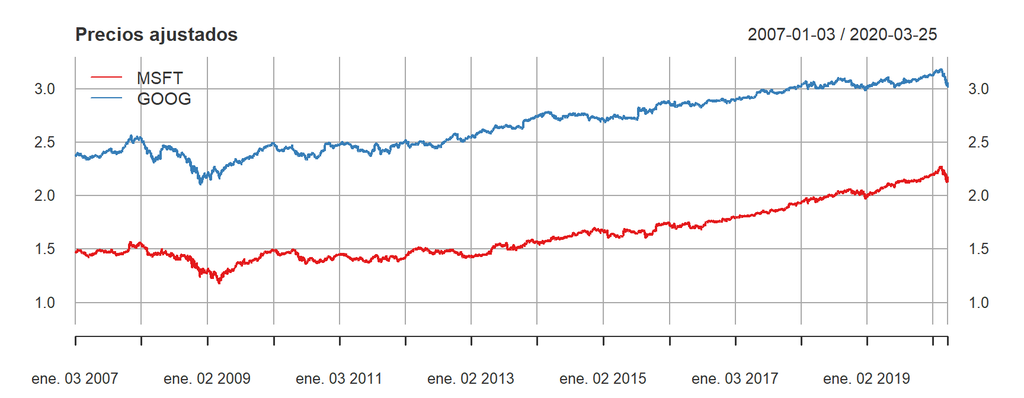

```r
addLegend(legend.loc = "topleft", legend.names = tracks, lty=1, col=brw_col[1:2])
```

## Estadísticos descriptivos

- Serie de pasajeros de aerolíneas (datos mensuales).

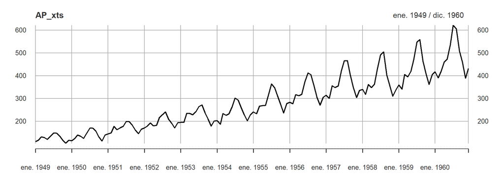

```r
AP_xts = as.xts(AirPassengers)
plot(AP_xts)
```

## Estadísticos descriptivos

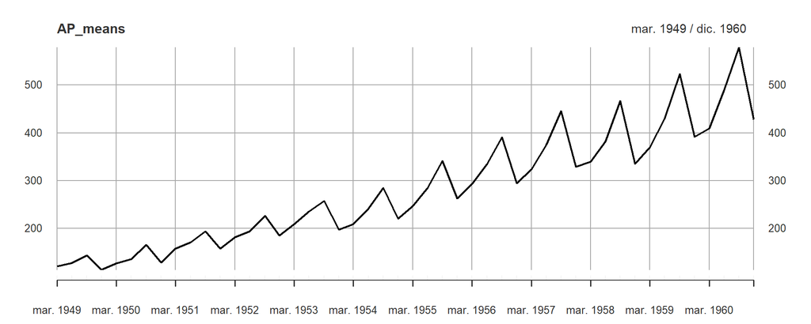

```r
AP_means = period.apply(AP_xts, INDEX = endpoints(AP_xts, on='quarters'), FUN = mean)
plot(AP_means, ylab = "Media móvil miles pasajeros")
```

## Estadísticos descriptivos

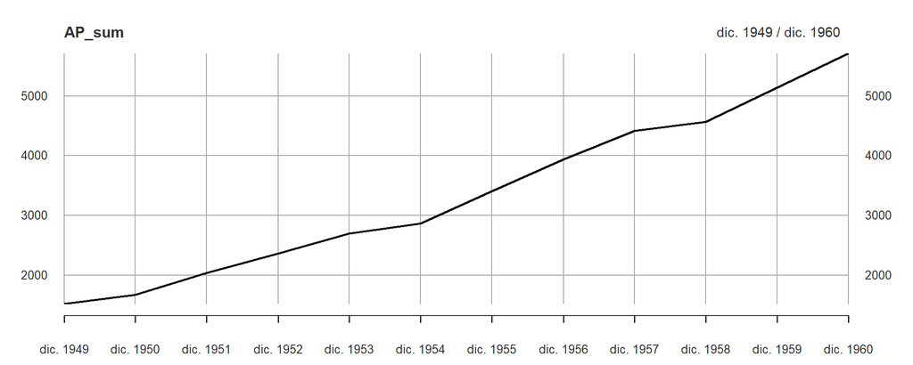

```r
AP_means = period.apply(AP_xts, INDEX = endpoints(AP_xts, on='months'), FUN = mean)
AP_sum = period.sum(AP_xts, INDEX = endpoints(AP_xts, on='years'))
plot(AP_sum, major.ticks = "years", ylab = "Acum. miles pasajeros")
```

## Descomposición STL

- En R, podemos usar la función `decompose` para intentar detectar la componente estacional de una serie temporal. En concreto:

```r
decompose(serie, type="add")  # Efecto aditivo (A)
decompose(serie, type="mul")  # Efecto multiplicativo (C)
```

- Otra opción más sofisticada es emplear la función `stl()` (ver ejemplo en el documento “6.4 Resumen de Series Temporales” en este mismo tema).
  - *Seasonality and Trend decomposition using Loess*.
  - https://otexts.com/fpp3/stl.html.

## Descomposición STL: ejemplo

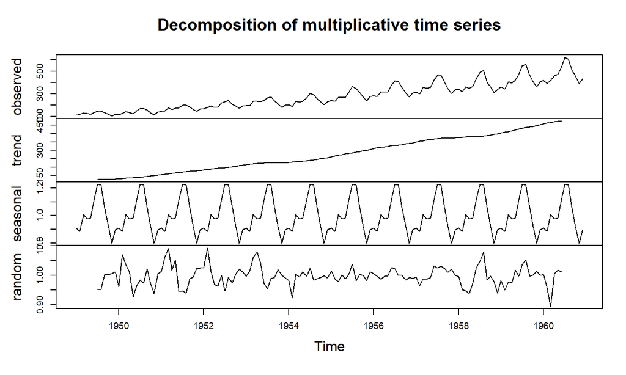

Descomposición en componente de tendencia y estacional de la serie temporal de evolución de pasajeros internacionales en compañías aéreas.

```r
AP_decomp = decompose(AirPassengers, type = "mul")
plot(AP_decomp)
```

## Descomposición STL: reconstrucción

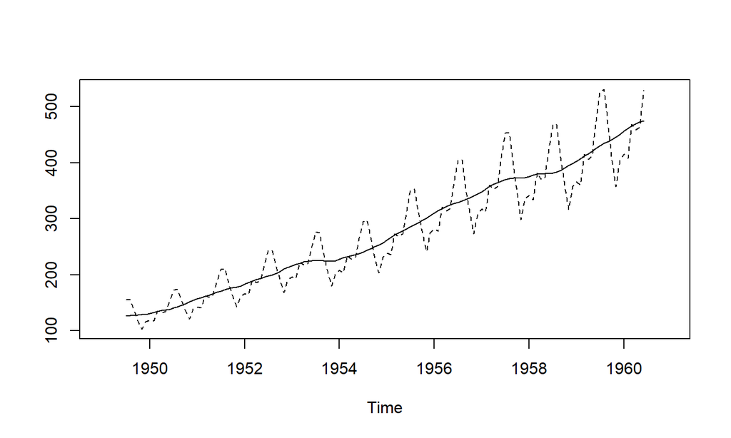

```r
ts.plot(cbind(AP_decomp$trend, AP_decomp$trend * AP_decomp$seasonal), lty=1:2)
```

## Media, varianza y autocovarianza

- En análisis de datos transversales, los valores que provienen de una cierta distribución de probabilidad se caracterizan, entre otros aspectos, por su media y su varianza (o desviación típica).
- En series temporales esta información no es suficiente, y se suelen calcular tres estadísticos de interés.
- **Media** o **esperanza**: La función media, \(\mu(t)\), se define para todo \(t\) como:

\[\mu(t)\; = \; E[X(t)]\]

- **Varianza**: La función varianza, \(\sigma^2(t)\), se define para todo \(t\) como:

\[\sigma^2(t)\; = \; Var[X(t)]\]

- **Autocovarianza**: La función de autocovarianza (abreviada como acf. o acv.f.) mide la covarianza entre valores de la señal en instantes de tiempo diferentes:

\[\gamma(t_1, t_2)\; = \; E\{[X(t_1)-\mu(t_1)][X(t_2)-\mu(t_2)]\}\]

## Media, varianza y autocovarianza (estimación)

- Las funciones descriptivas son desconocidas en su forma general. Por ello, el único recurso que tenemos (al igual que en análisis de datos transversales) es intentar **estimarlas** a partir de la **realización empírica del proceso**.
- Un **estimador empírico** para la **media** del proceso es la **esperanza de los valores observados** en la serie (considerada como realización de ese proceso):

\[\mu_t = E[x_t]\]

- Para la **varianza** del proceso, tenemos la **varianza de los valores observados** en la serie temporal:

\[\sigma^2_t\; = \; Var[x_t]\]

- Y para la **autocovarianza** del proceso, tenemos la **autocovarianza empírica de los valores observados** en la serie que, en general, puede tener un valor diferente para cada dos instantes de tiempo \(t_1\) y \(t_2\) seleccionados:

\[\gamma_{t_1, t_2} = E[(x_{t_1} - \bar{x}_{t_1})(x_{t_2} - \bar{x}_{t_2})]\]

## Función de autocorrelación (ACF)

\[\rho(t_1, t_2) = \frac{\gamma(t_1, t_2)}{\sigma(t_1)\sigma(t_2)}\]

\[r_1\; = \; \frac{\displaystyle\sum_{t=1}^{N-1}(x_t-\bar{x})(x_{t+1}-\bar{x})} {\displaystyle\sum_{t=1}^{N-1}(x_t-\bar{x})^2}\]

## Función de autocorrelación (ACF)

- Mientras que para un retardo arbitrario \(t_2 - t_1 = k\) tenemos:

\[r_k\; = \; \frac{\displaystyle\sum_{t=1}^{N-1}(x_t-\bar{x})(x_{t+k}-\bar{x})} {\displaystyle\sum_{t=1}^{N-1}(x_t-\bar{x})^2}\]

- En R, la ACF se calcula mediante la función `acf()`.

## Ejemplo: ACF correlación moderada

- Para una serie temporal con una correlación moderada entre valores consecutivos, tendremos unos cuantos coeficientes de la ac.f. significativos, y el resto no lo serán.

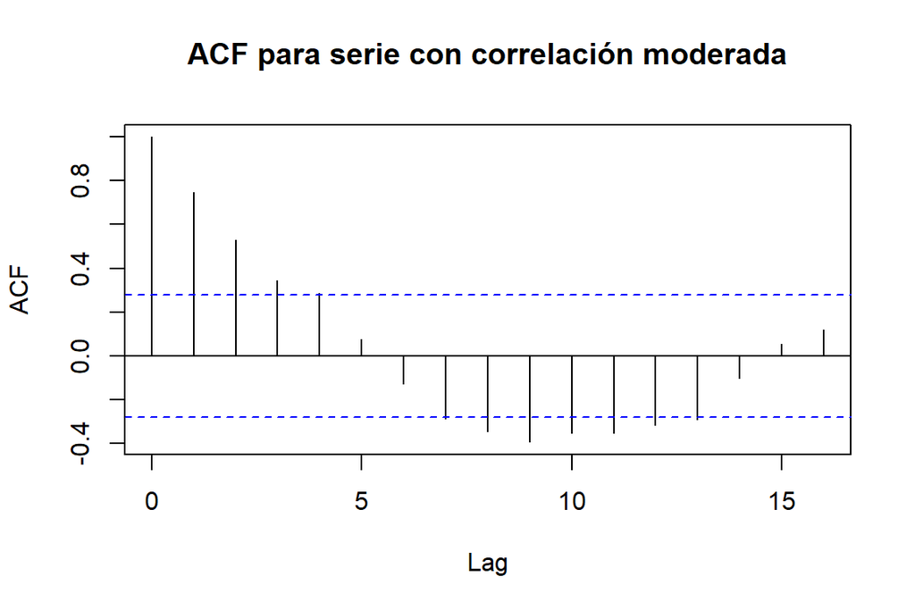

Correlograma para una serie de correlación moderada.

```r
acf(ts(c(9, 11, 10, 8, 7, 5, 6, 5, 7, 8, 9, 10, 12, 9, 13, 10, 11, 8, 10, 8, 7, 5, 4, 6, 8, 10, 12,
         9, 11, 14, 16, 13, 11, 13, 15, 13, 9, 7, 8, 6, 5, 5, 7, 5, 7, 9, 6, 4, 5)),
    main="ACF para serie con correlación moderada")
```

## Ejemplo: ACF valores alternados

Para una serie temporal con valores consecutivos alternados (subidas y bajadas constantes), la ac.f. también mostrará ese patrón. \(r_1\) será negativa (para un retardo de 1 los valores de la serie tiene sentidos opuestos). \(r_2\) será positiva (para un retardo de 2 los valores de la serie vuelven a tener el mismo sentido).

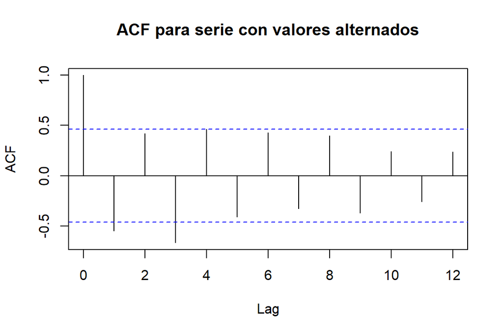

Correlograma para una serie con valores alternados

```r
acf(ts(c(100, 60, 90, 50, 120, 80, 140, 70, 120, 40, 80, 100, 150, 50, 110, 60, 130, 70)),
    main="ACF para serie con valores alternados")
```

## Función de autocorrelación parcial (PACF)

Se define la autocorrelación parcial en el retardo \(k\) como la correlación que resulta después de eliminar el efecto de cualquier correlación en retardos más cortos (Cowpertwait y Metcalfe 2009).

- En R se calcula mediante la función `pacf(...)`:

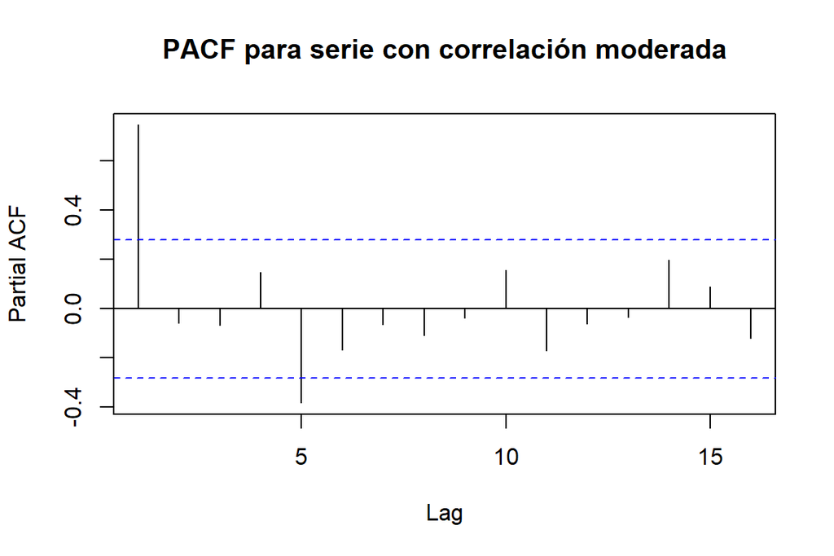

```r
pacf(ts(c(9, 11, 10, 8, 7, 5, 6, 5, 7, 8, 9, 10, 12, 9, 13, 10, 11, 8, 10, 8, 7, 5, 4, 6, 8, 10,
          12, 9, 11, 14, 16, 13, 11, 13, 15, 13, 9, 7, 8, 6, 5, 5, 7, 5, 7, 9, 6, 4, 5)),
    main="PACF para serie con correlación moderada")
```

## Referencias

- C. Chatfield. *The Analysis of Time Series. An Introduction*. 6th Ed. CRC Press, 2004.
- Wayne A. Woodward, Henry L. Gray, Alan C. Eliott. *Applied Time Series Analysis with R*. CRC Press, 2017.
- Box, G.E.P, Jenkins, G.M., Reinsel, G.C. y Ljung, G.M. *Time Series Analysis: Forecasting and Control*. Wiley Series in Probability and Statistics, 2015.
- Cowpertwait, P.S.P. y Metcalfe, Andrew V. *Introductory time series with R*. Springer, 2009.
- Cleveland, R.B., Cleveland, W. S., McRae, J.E. y Terpenning, I. (1990) *STL: A Seasonal-Trend Decomposition Procedure Based on Loess*. Journal of Official Statistics, 6, 3–73.